# Exploring the Nature of Travel

## The nature of my data

This data collects information on trips taken by me, my family and my friends, including information on the reason behind each trip, the price and distance of the trip and the method of travelling on the trip. The purpose of this data is to analyze what each transport method is used for, whether it be long distance travel, travelling to and from school or work, or short simple travelling for shopping or exercise.

## How transport use and travel purpose varies over the week

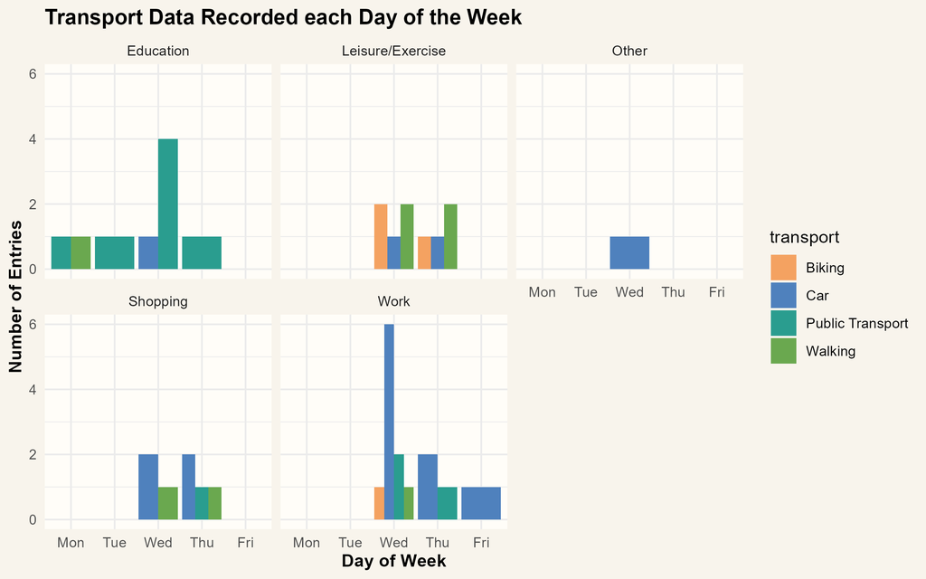

Bar chart showcasing transport usage over each day of the week, separated by the purpose of travel.

This graph shows that there is variance in transport usage depending on the day of the week, with most observations being recorded on Wednesdays and car travelling being the most common transport method recorded. Cars are commonly used in work travel compared to other transport methods. There is the possibility that some data was observed on different days and recorded on later days, so the data may not perfectly represent the timing of the travels.

## Comparing the mean distances travelled for each type of transport

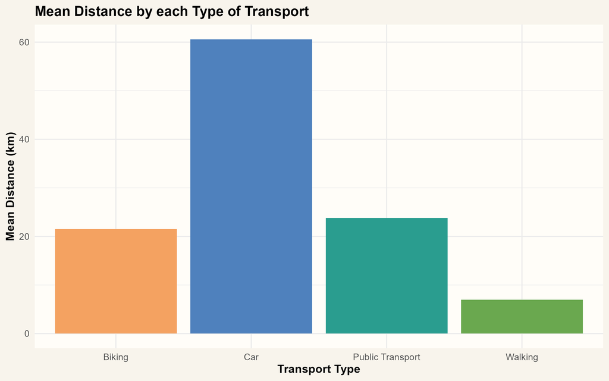

Bar chart showcasing mean distance travelled with each transport type.